# Cyclistic_2023_analysis

Atharv Verma

2024-11-01

# Cyclistic Bike-Share 2023 Analysis

### Step-1: Data Gathering

The preprocessed data is stored in overall_data_2023.csv file from the database.

#### Loading libraries

```r
library(tidyverse)
```

```r
library(dplyr)
library(tidyr)
library(ggplot2)
library(scales)
```

#### Importing data:

```r
tripdata <- read.csv("overall_data_2023.csv", header = TRUE, sep = ",")
tripdata
```

[output not shown]

[output cut: 18736 more lines]

### Step-2: Statistics

#### Summary Stats:

summary_stats shows the general stats of the data.

```r
mode_start_day <- tripdata %>%
  count(start_day) %>%
  filter(n == max(n)) %>%
  pull(start_day)

summary_stats <- tripdata %>%
  summarise(mean_duration = mean(duration, na.rm = TRUE),
            max_duration = max(duration, na.rm = TRUE),
            total_casual_riders = sum(membership_type == "casual", na.rm = TRUE),
            total_member_riders = sum(membership_type == "member", na.rm = TRUE),
            mode_start_day = mode_start_day)

print(summary_stats)
```

```
##   mean_duration max_duration total_casual_riders total_member_riders
## 1      18.26345        98489             4078350             7171103
##   mode_start_day
## 1      Saturday
```

- Average ride duration: 18 minutes approx.
- Max ride duration: 98489 minutes
- Total Casual Rides in 2023: 4,078,350
- Total Member Rides in 2023: 7,171,103
- Most frequent rides on: Saturday

#### Duration Stats:

Statistics of ride duration for casual and member riders.

```r
duration_stats <- tripdata %>%
  group_by(membership_type) %>%
  summarise(mean_duration = mean(duration, na.rm = TRUE),
            max_duration = max(duration, na.rm = TRUE),
            median_duration = median(duration, na.rm = TRUE),
            total_riders = n())
print(duration_stats)
```

```
## # A tibble: 2 × 5
##   membership_type mean_duration max_duration median_duration total_riders
##   <chr>                   <dbl>        <int>           <dbl>        <int>
## 1 casual                   28.3        98489              12      4078350
## 2 member                   12.6         1560               9      7171103
```

#### Day Stats:

Statistics of start day for casual and member riders.

```r
day_stats <- tripdata %>%
  mutate(start_day = str_trim(start_day)) %>%
  group_by(membership_type, start_day) %>%
  summarise(total_rides = n()) %>%
  mutate(start_day = factor(start_day, levels = c("Sunday", "Monday", "Tuesday", "Wednesday", "Thursday", "Friday", "Saturday"))) %>%
  arrange(membership_type, start_day)
print(day_stats)
```

```
## # A tibble: 14 × 3
## # Groups:   membership_type [2]
##    membership_type start_day total_rides
##    <chr>           <fct>           <int>
##  1 casual          Sunday         665059
##  2 casual          Monday         463958
##  3 casual          Tuesday        485544
##  4 casual          Wednesday      492354
##  5 casual          Thursday       536202
##  6 casual          Friday         618838
##  7 casual          Saturday       816395
##  8 member          Sunday         801731
##  9 member          Monday         966503
## 10 member          Tuesday       1124131
## 11 member          Wednesday     1148175
## 12 member          Thursday      1156535
## 13 member          Friday        1043089
## 14 member          Saturday       930939
```

#### Time of Day Stats:

Statistics of time of day for casual and member riders.

```r
time_of_day_stats <- tripdata %>%
  group_by(membership_type, time_of_day) %>%
  summarise(total_rides = n()) %>%
  arrange(membership_type, time_of_day)
print(time_of_day_stats)
```

```
## # A tibble: 8 × 3
## # Groups:   membership_type [2]
##   membership_type time_of_day total_rides
##   <chr>           <chr>             <int>
## 1 casual          Afternoon       1489359
## 2 casual          Evening         1171402
## 3 casual          Morning          854703
## 4 casual          Night            562886
## 5 member          Afternoon       2308342
## 6 member          Evening         2090845
## 7 member          Morning         2088302
## 8 member          Night            683614
```

#### Bike Type Stats:

Statistics of bike type used by casual and member riders.

```r
bike_type_stats <- tripdata %>%
  group_by(membership_type, bike_type) %>%
  summarise(total_rides = n()) %>%
  arrange(membership_type, -total_rides)
print(bike_type_stats)
```

```
## # A tibble: 5 × 3
## # Groups:   membership_type [2]
##   membership_type bike_type     total_rides
##   <chr>           <chr>               <int>
## 1 casual          electric_bike     2183661
## 2 casual          classic_bike      1739853
## 3 casual          docked_bike        154836
## 4 member          electric_bike     3609228
## 5 member          classic_bike      3561875
```

#### Month Stats:

Statistics of Start month of rides by casual and member riders.

```r
month_stats <- tripdata %>%
  mutate(start_month = str_trim(start_month)) %>%
  group_by(membership_type, start_month) %>%
  summarise(total_rides = n()) %>%
  mutate(start_month = factor(start_month, levels = c("January", "February", "March", "April", "May", "June", "July", "August", "September", "October", "November", "December"))) %>%
  arrange(start_month)
print(month_stats)
```

```
## # A tibble: 24 × 3
## # Groups:   membership_type [2]
##    membership_type start_month total_rides
##    <chr>           <fct>             <int>
##  1 casual          January           40008
##  2 member          January          150293
##  3 casual          February          86032
##  4 member          February         294858
##  5 casual          March            124402
##  6 member          March            392954
##  7 casual          April            294570
##  8 member          April            558610
##  9 casual          May              468362
## 10 member          May              741292
## # ℹ 14 more rows
```

#### Hour Stats:

Statistics of Start hour of rides by casual and member riders.

```r
hour_stats <- tripdata %>%
  group_by(membership_type, start_hour) %>%
  summarise(total_rides = n(), .groups = 'drop') %>%
  mutate(start_hour = factor(start_hour,
                             levels = c("12 AM", "1 AM", "2 AM", "3 AM", "4 AM", "5 AM", "6 AM", "7 AM",
                                        "8 AM", "9 AM", "10 AM", "11 AM",
                                        "12 PM", "1 PM", "2 PM", "3 PM", "4 PM", "5 PM", "6 PM", "7 PM",
                                        "8 PM", "9 PM", "10 PM", "11 PM"))) %>%
  arrange(membership_type, start_hour)
print(hour_stats)
```

```
## # A tibble: 48 × 3
##    membership_type start_hour total_rides
##    <chr>           <fct>            <int>
##  1 casual          12 AM            73066
##  2 casual          1 AM             47278
##  3 casual          2 AM             28479
##  4 casual          3 AM             15709
##  5 casual          4 AM             11731
##  6 casual          5 AM             22501
##  7 casual          6 AM             59364
##  8 casual          7 AM            104417
##  9 casual          8 AM            139525
## 10 casual          9 AM            138425
## # ℹ 38 more rows
```

#### Season Stats:

Statistics of season of rides by casual and member riders.

```r
season_membership_stats <- tripdata %>%
  group_by(membership_type, season) %>%
  summarise(total_rides = n())
print(season_membership_stats)
```

```
## # A tibble: 8 × 3
## # Groups:   membership_type [2]
##   membership_type season total_rides
##   <chr>           <chr>        <int>
## 1 casual          Autumn     1074196
## 2 casual          Spring      887334
## 3 casual          Summer     1887436
## 4 casual          Winter      229384
## 5 member          Autumn     2057808
## 6 member          Spring     1692856
## 7 member          Summer     2630486
## 8 member          Winter      789953
```

#### Season Percentage Stats:

Statistics of season percentage rides of total riders.

```r
season_stats <- tripdata %>%
  group_by(season) %>%
  summarise(total_rides = n()) %>%
  mutate(percentage = total_rides / sum(total_rides) * 100)  # Calculate percentage
print(season_stats)
```

```
## # A tibble: 4 × 3
##   season total_rides percentage
##   <chr>        <int>      <dbl>
## 1 Autumn     3132004      27.8
## 2 Spring     2580190      22.9
## 3 Summer     4517922      40.2
## 4 Winter     1019337       9.06
```

### Step-3: Visualization and Insights

#### Ride Duration by Membership Type

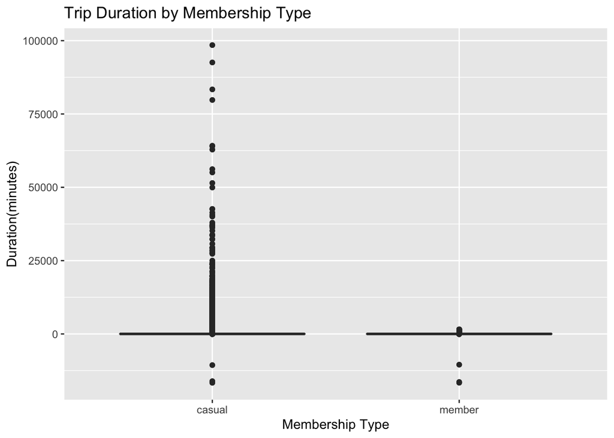

**Insights:**

- Casual riders ride for longer duration.
- Casual ride duration is scattered and varying.
- Member riders ride for shorter duration.
- Member ride duration is fairly consistent for majority of riders.

#### Ride by Days of Week

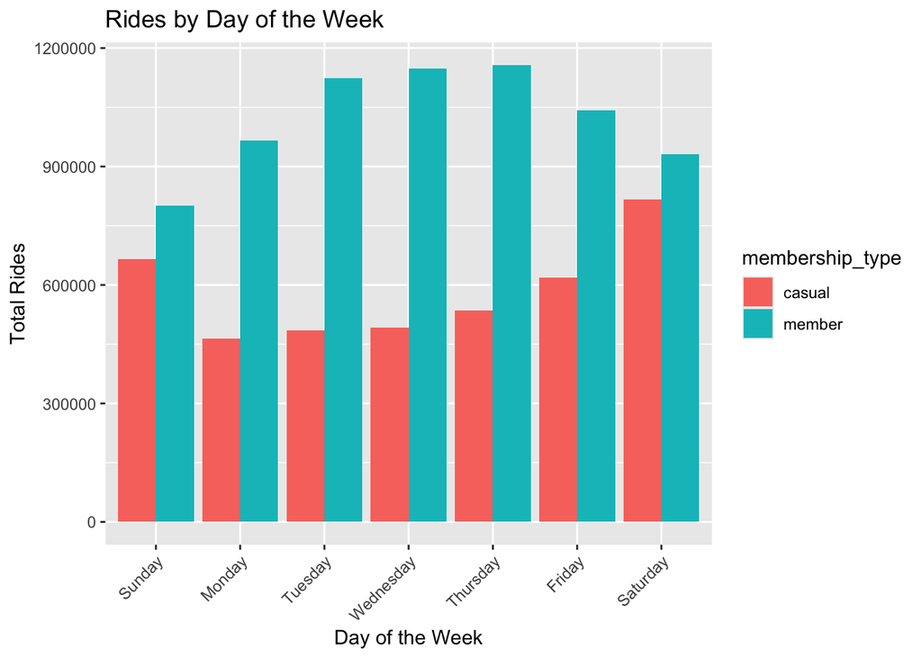

```r
ggplot(day_stats, aes(x = start_day, y=total_rides, fill = membership_type)) + geom_bar(stat = "identity", position = "dodge") +
  labs(title = "Rides by Day of the Week", x = "Day of the Week", y = "Total Rides")+
  theme(axis.text.x = element_text(angle = 45, hjust = 1))
```

**Insights:**

- Casual rides are almost half of Member rides during weekdays.
- Casual rides almost catch upto Member rides on weekends.
- Casual riders use more rides on weekends.
- Member riders use more rides on weekdays.

#### Ride by Time of Day

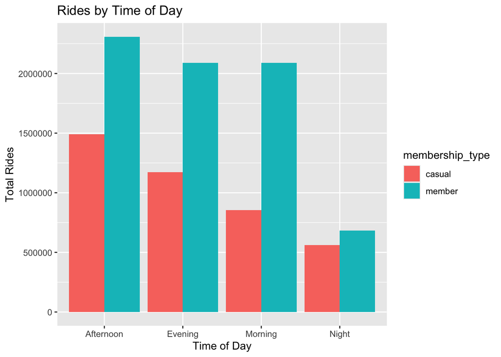

```r
#Rides by Time of Day
ggplot(time_of_day_stats, aes(x = time_of_day, y=total_rides, fill = membership_type)) +
  geom_bar(stat = "identity", position = "dodge") +
  labs(title = "Rides by Time of Day", x = "Time of Day", y="Total Rides")
```

**Insights:**

- Both casual and member riders use bike rides during Afternoon hours the most.
- Total rides are the lowest during Night hours for both casual and member riders.

#### Bike Type Usage by Membership Type

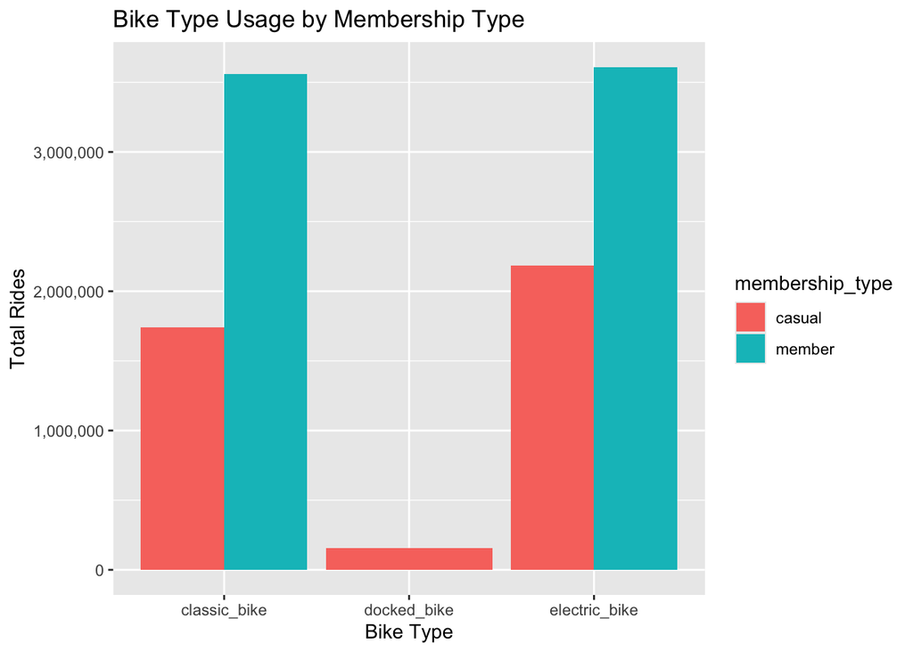

```r
#Bike Type Usage
library(scales)
ggplot(bike_type_stats, aes(x = bike_type, y = total_rides, fill = membership_type)) +
  geom_bar(stat = "identity", position = "dodge") +
  labs(
    title = "Bike Type Usage by Membership Type",
    x = "Bike Type",
    y="Total Rides"
    ) +
  scale_y_continuous(labels = scales::comma)
```

**Insights:**

- Docked bikes are only booked by Casual riders.
- Member riders do not book docked bikes.

#### Rides by Month

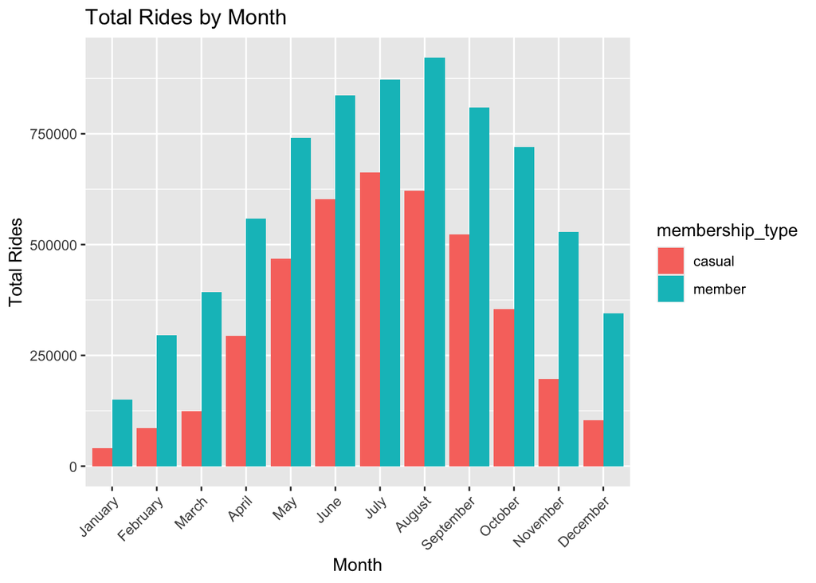

```r
ggplot(month_stats, aes(x = start_month, y = total_rides, fill = membership_type)) +
  geom_bar(stat = "identity", position = "dodge") +
  labs(title = "Total Rides by Month", x = "Month", y = "Total Rides") +
  theme(axis.text.x = element_text(angle = 45, hjust = 1))
```

**Insights:**

- Hot months like June, July, and August are the busiest.

#### Rides by Hour

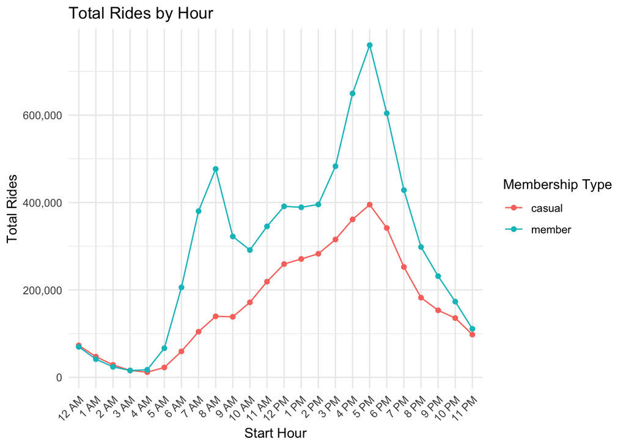

```r
ggplot(hour_stats, aes(x = start_hour, y = total_rides, color = membership_type, group = membership_type)) +
  geom_line() +
  geom_point() +
  labs(
    title = "Total Rides by Hour",
    x = "Start Hour",
    y = "Total Rides",
    color = "Membership Type"
  ) +
  scale_y_continuous(labels = scales::comma) +
  theme_minimal() +
  theme(axis.text.x = element_text(angle = 45, hjust = 1))
```

**Insights:**

- Casual rides peaks till 5PM.
- Member rides correlates to the standard office hours.

#### Rides by Season

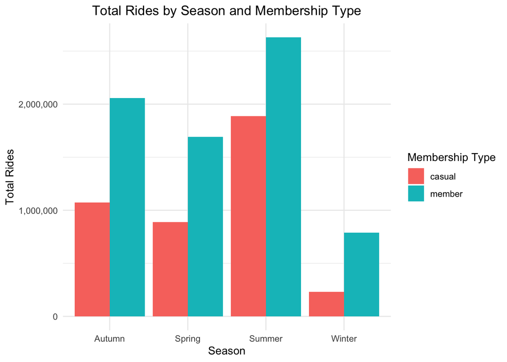

```r
# Create a bar chart
ggplot(season_membership_stats, aes(x = season, y = total_rides, fill = membership_type)) +
  geom_bar(stat = "identity", position = position_dodge()) +  # Position bars side by side
  labs(
    title = "Total Rides by Season and Membership Type",
    x = "Season",
    y = "Total Rides",
    fill = "Membership Type"
  ) +
  scale_y_continuous(labels = scales::comma) +
  theme_minimal() +  # Use a minimal theme
  theme(
    plot.title = element_text(hjust = 0.5)  # Center title
  )
```

```r
season_stats <- tripdata %>%
  group_by(season) %>%
  summarise(total_rides = n()) %>%
  mutate(percentage = total_rides / sum(total_rides) * 100)  # Calculate percentage
print(season_stats)
```

```
## # A tibble: 4 × 3
##   season total_rides percentage
##   <chr>        <int>      <dbl>
## 1 Autumn     3132004      27.8
## 2 Spring     2580190      22.9
## 3 Summer     4517922      40.2
## 4 Winter     1019337       9.06
```

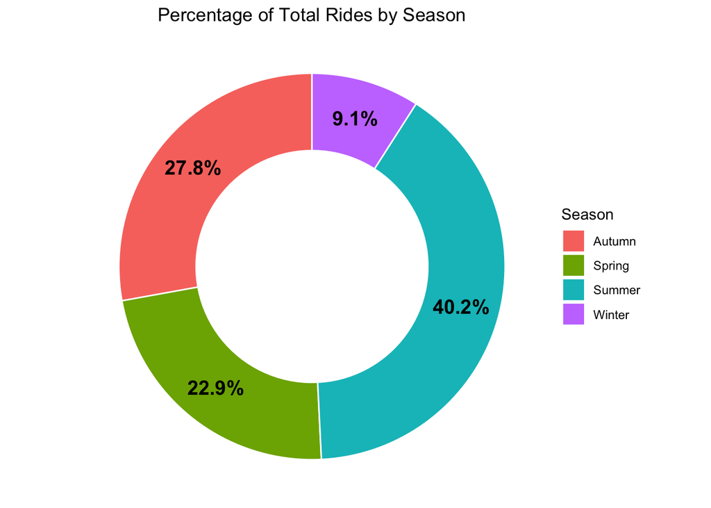

```r
# Create a donut chart
ggplot(season_stats, aes(x = "", y = total_rides, fill = season)) +
  geom_bar(stat = "identity", width = 0.5, position = "stack", color = "white") +  # Create bars with white border
  coord_polar("y") +  # Convert to polar coordinates
  labs(
    title = "Percentage of Total Rides by Season",
    fill = "Season"
  ) +
  theme_void() +  # Remove axes and grid
  theme(
    plot.title = element_text(hjust = 0.5),  # Center title
    legend.position = "right"  # Position legend
  ) +
  # Create the hole for the donut
  geom_polygon(data = data.frame(x = 0, y = 0, r = 0.4),
               aes(x = x, y = y), fill = "white", inherit.aes = FALSE) +  # Create the donut hole
  # Add percentage labels on the donut segments
  geom_text(aes(label = paste0(round(percentage, 1), "%")),
            position = position_stack(vjust = 0.5),
            color = "black", size = 5, fontface = "bold")  # Adjust text size and style
```

**Insights:**

- Summer months are the busiest.
- Massive fall-out in Winter months.